# Esfuerzo, oportunidad y reparto de décimas

[figure not shown]

## **Esfuerzo, oportunidad y reparto de décimas**

Modelos multinivel para el experimento distribucional (DSE)

**Encuesta panel Educación y Meritocracia (EDUMER), ola 2**

Nicolás Outerbridge

## El proyecto EDUMER

[figure not shown]

- **Educación y Meritocracia (EDUMER):** estudia cómo niños, niñas y adolescentes aprenden a pensar la **meritocracia**, la **justicia** y la **desigualdad** en la escuela.
- Origen: proyecto ANID/FONDECYT N° 1210847, *Meritocracia en la escuela: fundamentos morales del mercado educativo y sus implicancias para la formación ciudadana en Chile*.
- **Encuesta panel** a estudiantes y apoderados de **9 escuelas** de la Región Metropolitana, en **dos olas** (2023 y 2024).
- Mide percepciones y preferencias sobre meritocracia, justicia de mercado y creencias sobre el esfuerzo, e incluye **experimentos de encuesta**.
- Esta presentación: el **experimento distribucional** de la **ola 2** (7° básico y 2° medio).

Más información: [jc-castillo.com/project/fondecyt-edumer](https://jc-castillo.com/project/fondecyt-edumer/) · github.com/educacion-meritocracia

# El experimento

## ¿Cómo repartirías tú?

Tu curso tiene **10 décimas** para regalar. Cuatro compañeros tienen un **3,7** y les faltan **3 décimas** para aprobar con un 4,0. **Tú decides** cuántas recibe cada uno.

A

nota 3,7

Se esfuerza **más** que la mayoría.

Su casa es **pequeña**: no tiene un espacio cómodo para estudiar.

___ décimas

B

nota 3,7

Se esfuerza **menos** que la mayoría.

Su casa es **grande**: tiene un espacio cómodo para estudiar.

___ décimas

C

nota 3,7

Se esfuerza **más** que la mayoría.

Su casa es **grande**: tiene un espacio cómodo para estudiar.

___ décimas

D

nota 3,7

Se esfuerza **menos** que la mayoría.

Su casa es **pequeña**: no tiene un espacio cómodo para estudiar.

___ décimas

Las décimas solo alcanzan para que aprueben **tres**. ¿A quién dejas reprobar?

¿Pesa más el esfuerzo o las condiciones en que cada uno estudia?

## ¿Qué es un experimento distribucional?

- Cada estudiante reparte **10 décimas** entre **cuatro compañeros ficticios**.
- Los cuatro tienen nota **3,7**: con 3 décimas llegan al 4,0 y aprueban.
- Los compañeros cruzan dos atributos en un **diseño factorial 2×2**:
  - **Esfuerzo:** se esfuerza más o menos que la mayoría.
  - **Oportunidad:** casa grande o pequeña para estudiar.
- Lo que se da a uno se le quita a otro: el reparto revela **qué se considera justo premiar** (Gilgen, 2022; Gilgen y Zangger, 2025).

| Perfil | Esfuerzo | Casa |
| --- | --- | --- |
| **A** | Más | Pequeña |
| **B** | Menos | Grande |
| **C** | Más | Grande |
| **D** | Menos | Pequeña |

EDUMER, ola 2: 657 estudiantes de 7° básico y 2° medio, con reparto válido y respuesta en los moderadores.

## ¿Cómo reparten?

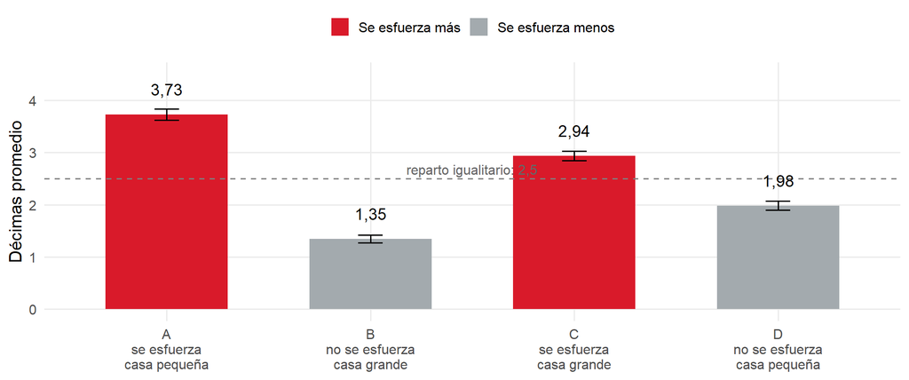

Se **premia el esfuerzo** (A y C) y, con igual esfuerzo, se **compensa** a la casa pequeña (A > C, D > B).

## Los repartos más frecuentes

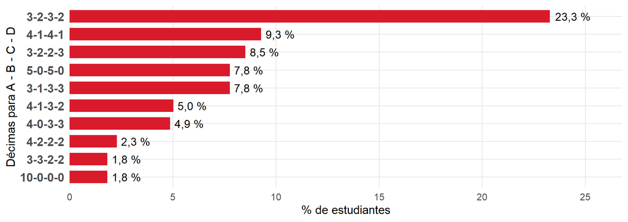

Hay 66 repartos distintos, pero los 10 más frecuentes reúnen al 72 % de los estudiantes. El más común, **3-2-3-2**, es casi igualitario, con una leve ventaja al esfuerzo; le siguen repartos que **solo premian el esfuerzo** (4-1-4-1, 5-0-5-0) y otros que **solo compensan** (3-2-2-3).

# ¿Es pertinente un modelo multinivel?

## Estructura anidada de los datos

[figure not shown]

**Nivel 2, el estudiante:** sus actitudes tienen **un solo valor por persona** y se repiten en sus 4 decisiones. Por eso son variables de nivel 2.

**Nivel 1, la decisión:** esfuerzo y oportunidad **cambian entre las 4 decisiones** de una misma persona. Como las 4 las toma la misma persona y suman 10, **no son independientes**: el estudiante es la unidad de agrupamiento.

Ejemplo ilustrativo de tres estudiantes; los valores de las actitudes son inventados.

## La suma fija: lo que no puede variar entre estudiantes

- Cada estudiante reparte exactamente 10 décimas, así que **su promedio es siempre 2,5**.
- Modelo nulo: varianza del intercepto = **0,000**, correlación intraclase = **0**.

**Consecuencias:**

1. El intercepto aleatorio **no tiene varianza** que estimar.
2. Las variables del estudiante **no tienen efecto principal** sobre las décimas: valen 0 por construcción.
3. Solo pueden actuar **cambiando el peso** del esfuerzo o la oportunidad, es decir, a través de **interacciones entre niveles**.

Lo que sí varía entre estudiantes son las **pendientes**: cuánto pesa el esfuerzo y cuánto se compensa.

## Argumentos a favor y en contra

### A favor

- **Datos anidados:** 4 decisiones por estudiante, no independientes.
- **Heterogeneidad real:** el peso del esfuerzo varía mucho entre estudiantes, y las pendientes aleatorias la capturan.
- **Interacciones entre niveles:** sin pendientes aleatorias, sus errores estándar se subestiman (Heisig y Schaeffer, 2019).
- Es la **práctica habitual** en encuestas factoriales.

### En contra / cuidados

- **Suma fija:** sin varianza del intercepto, y dependencia negativa entre decisiones que el modelo no captura.
- **Pocos datos por persona:** cada estudiante toma solo 4 decisiones, y como deben sumar 10, la última queda determinada por las otras tres. Hay poca información por persona para estimar cuánto pesa cada atributo para ella.

**Conclusión:** es **pertinente pero no indispensable**. Se justifica para estimar bien las interacciones y cuantificar la heterogeneidad entre estudiantes.

## Lo que muestran los datos

|  | M1: sin pendientes aleatorias | M2: con pendientes aleatorias |
| --- | --- | --- |
| Intercepto | 2,50*** (0,023) | 2,50*** (0,016) |
| Esfuerzo (se esfuerza más) | 1,67*** (0,046) | 1,67*** (0,063) |
| Oportunidad (casa grande) | -0,71*** (0,046) | -0,71*** (0,050) |
| Varianzas aleatorias |  |  |
| Intercepto (estudiante) | 0,00 | 0,00 |
| Pendiente del esfuerzo |  | 1,95 |
| Pendiente de la oportunidad |  | 0,97 |
| Residual | 1,39 | 0,67 |
| Ajuste |  |  |
| Log-verosimilitud | -4.166,3 | -3.938,1 |
| AIC | 8.342,7 | 7.890,1 |
| BIC | 8.372,0 | 7.931,2 |
| Razón de verosimilitud χ² (gl) |  | 456,5*** (2) |

Coeficientes en décimas, con errores estándar entre paréntesis. Atributos codificados −0,5 / +0,5. Máxima verosimilitud. χ²: test de razón de verosimilitud de M2 frente a M1. * *p* < ,05; ** *p* < ,01; *** *p* < ,001.

- Las pendientes aleatorias **mejoran enormemente el ajuste** (χ²(2) = 456,5, *p* < ,001).
- El efecto promedio no cambia, pero **su error estándar crece un 37 %**: sin ellas se subestima la incertidumbre.
- La *DE* de la pendiente (1,40) es **casi tan grande como el efecto promedio**: hay mucha heterogeneidad que explicar.

# Modelos

## ¿Qué vamos a probar?

[figure not shown]

Cada flecha roja es una **interacción entre niveles**: ¿cambia el peso del esfuerzo o de la oportunidad según lo que cree el estudiante? Cada una se prueba **en un modelo distinto**.

## Estrategia

| Modelo | Componentes |
| --- | --- |
| **M1** | Efectos de nivel 1 (esfuerzo y oportunidad) + intercepto aleatorio |
| **M2** | M1 + pendientes aleatorias del esfuerzo y la oportunidad |
| **M3** | M2 + *mindset esfuerzo* + Esfuerzo × *mindset esfuerzo* |
| **M4** | M2 + *contactos importan en Chile* + Esfuerzo × *contactos* |
| **M5** | M2 + *meritocracia en la escuela* + Oportunidad × *meritocracia* |

- Todos los modelos usan la misma muestra (2.628 decisiones, 657 estudiantes) y se estiman por máxima verosimilitud.

## Resultados

| Predictor | M1 | M2 | M3 | M4 | M5 |
| --- | --- | --- | --- | --- | --- |
| Intercepto | 2,50*** | 2,50*** | 2,50*** | 2,50*** | 2,50*** |
| Esfuerzo | 1,67*** | 1,67*** | 0,60* | 1,04*** | 1,67*** |
| Oportunidad (casa grande) | -0,71*** | -0,71*** | -0,71*** | -0,71*** | -1,21*** |
| Mindset esfuerzo |  |  | 0,00 |  |  |
| Contactos importan en Chile |  |  |  | 0,00 |  |
| Meritocracia en la escuela |  |  |  |  | 0,00 |
| Esfuerzo × Mindset esfuerzo |  |  | 0,32*** |  |  |
| Esfuerzo × Contactos importan en Chile |  |  |  | 0,20** |  |
| Oportunidad × Meritocracia en la escuela |  |  |  |  | 0,16* |
| Varianzas aleatorias |  |  |  |  |  |
| Pendiente del esfuerzo |  | 1,95 | 1,89 | 1,92 | 1,95 |
| Pendiente de la oportunidad |  | 0,97 | 0,97 | 0,97 | 0,95 |
| Residual | 1,39 | 0,67 | 0,67 | 0,67 | 0,67 |
| Ajuste |  |  |  |  |  |
| Log-verosimilitud | -4.166,3 | -3.938,1 | -3.930,2 | -3.934,4 | -3.935,0 |
| AIC | 8.342,7 | 7.890,1 | 7.878,5 | 7.886,8 | 7.888,1 |
| BIC | 8.372,0 | 7.931,2 | 7.931,3 | 7.939,6 | 7.940,9 |
| χ² |  | 456,5*** | 15,7*** | 7,4* | 6,1* |

Coeficientes en décimas. Atributos −0,5 / +0,5; moderadores en su escala original (interacciones por cada punto). En M3 a M5, el coeficiente de esfuerzo u oportunidad es su efecto con el moderador en 0, fuera de la escala, y no se interpreta (ver efectos marginales). Varianza del intercepto = 0 en todos los modelos (suma fija). χ²: M2 frente a M1; M3 a M5 frente a M2. * *p* < ,05; ** *p* < ,01; *** *p* < ,001. *N* = 2.628 decisiones de 657 estudiantes.

## Cómo cambian los efectos según el moderador

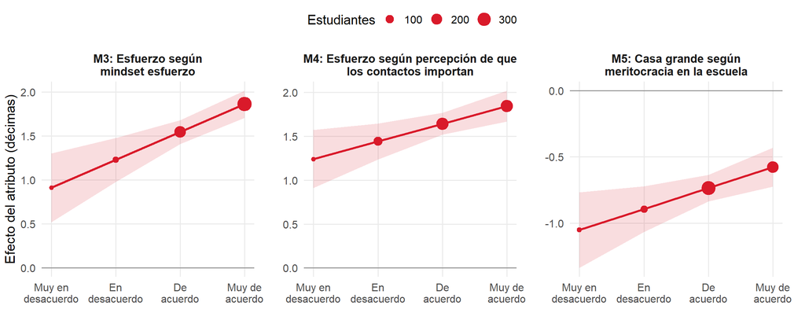

Efecto del atributo en cada valor del moderador, con IC 95 %. Esfuerzo: décimas adicionales al perfil que se esfuerza. Casa grande: valores negativos = compensación; más cerca de 0 = menos compensación.

## Lectura de los modelos

- Las interacciones se leen **por cada punto** de acuerdo; el efecto en cada nivel está en el gráfico anterior.
- **M1 → M2:** el esfuerzo suma **1,67 décimas** y la casa grande resta **0,71**. Las pendientes aleatorias muestran que ese peso **varía mucho** entre estudiantes.
- **M3, mindset esfuerzo:** **0,32 décimas más** de efecto del esfuerzo por cada punto de acuerdo (*p* < ,001).
- **M4, contactos:** quienes perciben que en Chile **no basta con el mérito** también premian **más** el esfuerzo (0,20; *p* = ,007). **Preferir** la meritocracia y **percibir** que no existe empujan en la misma dirección.
- **M5, meritocracia escolar:** quienes ven su escuela como meritocrática **compensan menos** (0,16; *p* = ,014).

# Conclusiones

## Conclusiones

1. **El experimento funciona:** los estudiantes **premian el esfuerzo** (≈ 1,7 décimas) y **compensan la desventaja** (≈ 0,7 décimas). Es una justicia sensible a la responsabilidad, no una meritocracia pura.
2. **Suma fija:** como cada estudiante reparte siempre 10 décimas, no hay varianza entre estudiantes en el nivel; las actitudes solo pueden actuar **cambiando el peso** del esfuerzo o la oportunidad (interacciones).
3. **Multinivel:** es **pertinente** para estimar bien las interacciones y medir la heterogeneidad entre estudiantes.
4. **Interacciones:** solo el **mindset esfuerzo** es robusto.
5. **Lo más importante:** hay **mucha heterogeneidad** en cómo reparten los estudiantes, y sus actitudes **explican poco** de ella.

## Referencias

Gilgen, S. (2022). *Disentangling justice: Needs, equality or merit? On the situation-dependency of distributive justice*. Nomos. https://doi.org/10.5771/9783748926955

Gilgen, S., y Zangger, C. (2025). From principles to practice: Distributive justice and the role of perceived inequality in reward allocation. *Frontiers in Sociology, 10*, 1660806. https://doi.org/10.3389/fsoc.2025.1660806

Heisig, J. P., y Schaeffer, M. (2019). Why you should always include a random slope for the lower-level variable involved in a cross-level interaction. *European Sociological Review, 35*(2), 258–279. https://doi.org/10.1093/esr/jcy053